# [Prototype] Suivi des étiages (ONDE) en Ile-de-France

OFB - Direction régionale Île-de-France

MAJ 28/11/2026 - 14:50

⚠️ Les données ci-dessous concernent les observations réalisées au plus tard :

- en **09/2026** pour les campagnes usuelles ;
- et en **10/2026** pour les campagnes complémentaires.

## Campagnes

Les cartes se lisent de la manière suivante :

- La forme des symboles correspond au type de campagne: carré pour les campagnes usuelles, rond pour les campagnes complémentaires ;
- La dernière campagne usuelle est représentée et seules les observations complémentaires postérieures à cette campagne sont représentées ;
- La couleur des symbole correspond à la situation des observations au cours de ces dernières campagnes ;
- La taille des symbole est proportionnelle à la fréquence des assecs sur les chroniques de données des campagnes usuelles ;
- En cliquant sur une station, un graphique de l’historique des observations et états d’écoulement peut être affiché. Ce graphique reprend la même symbologie que la carte ;
- Avec le menu déroulant (en haut à droite), différents éléments cartographiques peuvent être affichés (i.e. fonds de cartes, départements, assecs, zones d’alerte Propluvia).

Deux onglets pour les deux typologies d’observations sont distingués:

- **Typologie nationale** : **écoulement visible** ; **écoulement non visible** et **assec** ;
- **Typologie départementale** : **écoulement visible acceptable** ; **écoulement visible faible** ; **écoulement non visible** et **assec**.

Les **observations impossibles** et **données manquantes** sont également représentées.

**Campagne usuelle de septembre 2026**

### Typologie nationale

[interactive chart not shown]

### Typologie départementale

[interactive chart not shown]

## Bilan régional

### **Conditions d’écoulement lors des campagnes usuelles (mai à septembre 2026)**

#### Typologie nationale

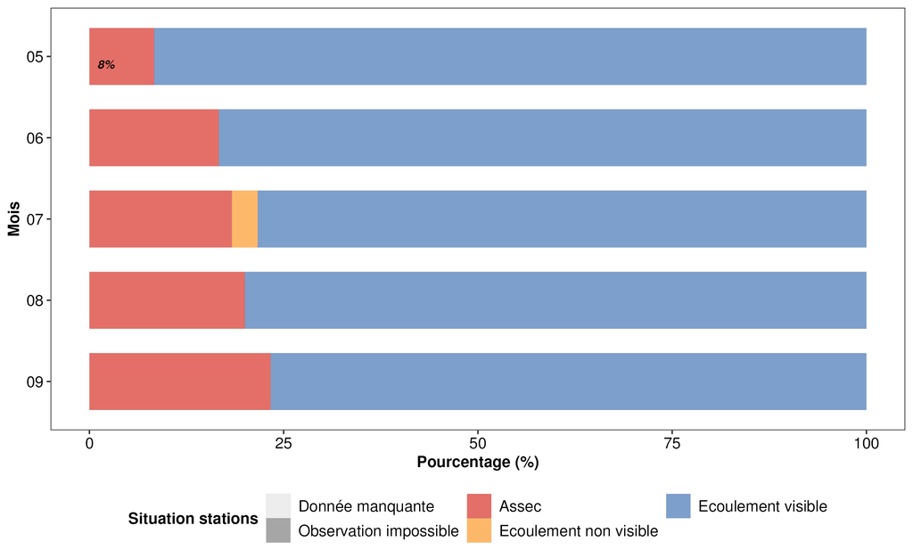

#### Typologie départementale

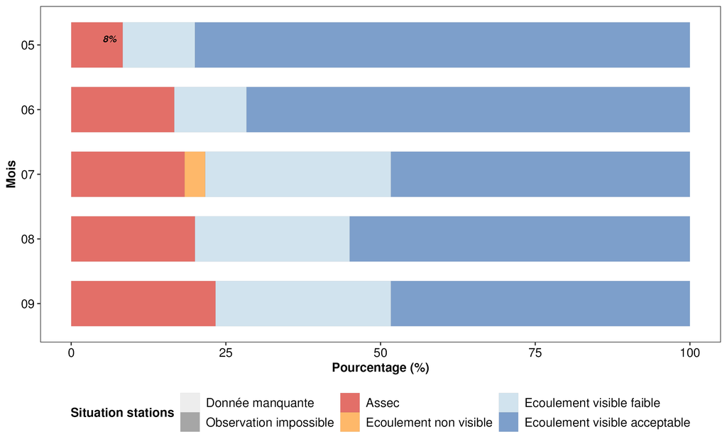

### **Sévérité des assecs**

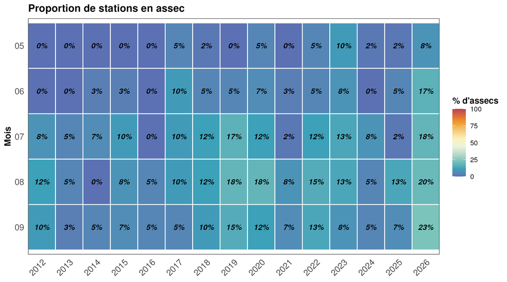

### **Des assecs se suivant d’un mois sur l’autre**

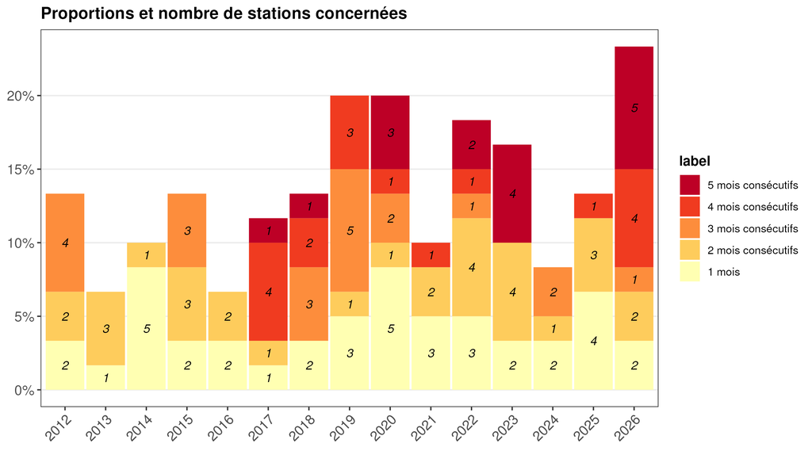

## Bilans départementaux

### 77

#### **Conditions d’écoulement lors des campagnes usuelles (mai à septembre 2026 )**

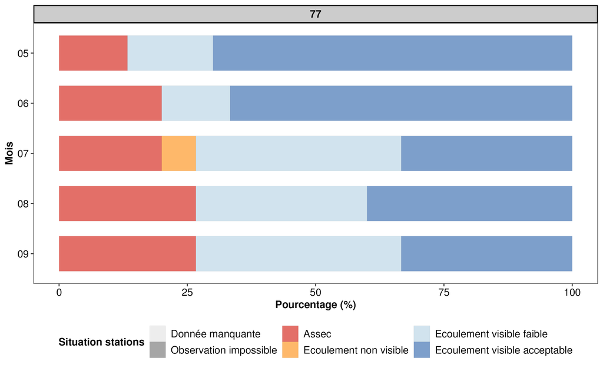

#### **Sévérité des assecs**

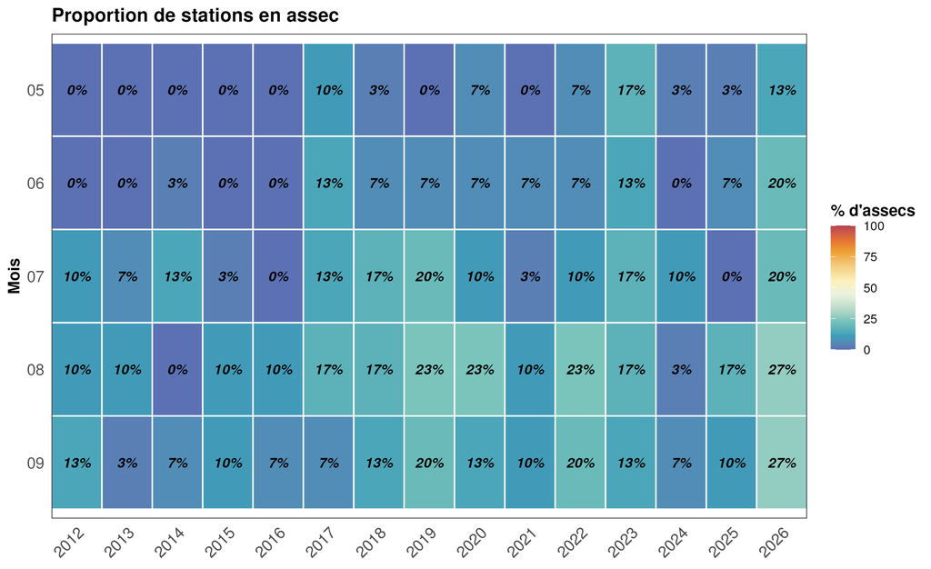

#### **Des assecs se suivant d’un mois sur l’autre**

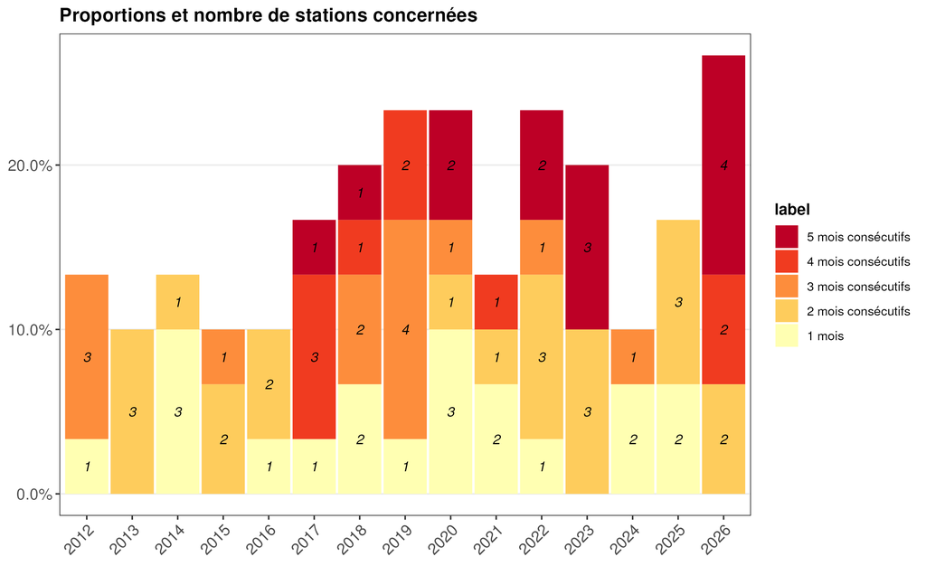

### 78

#### **Conditions d’écoulement lors des campagnes usuelles (mai à septembre 2026 )**

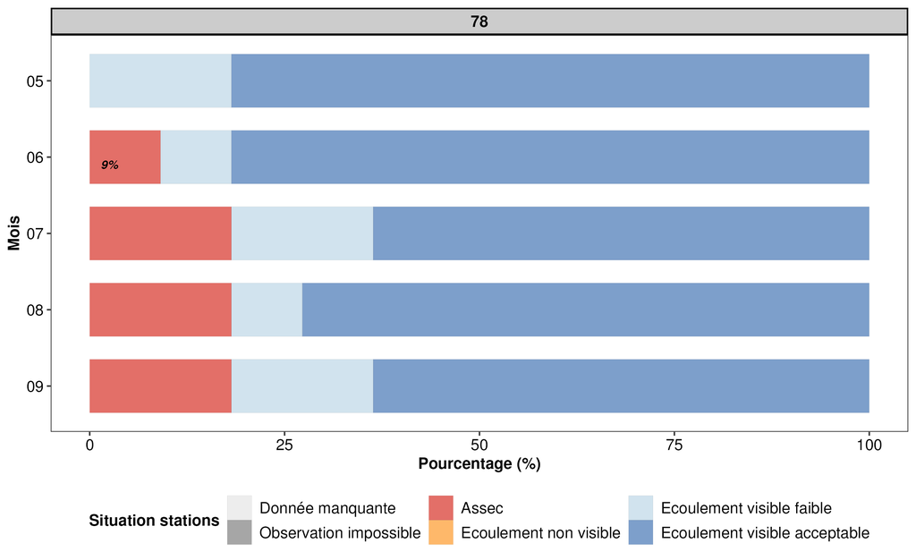

#### **Sévérité des assecs**

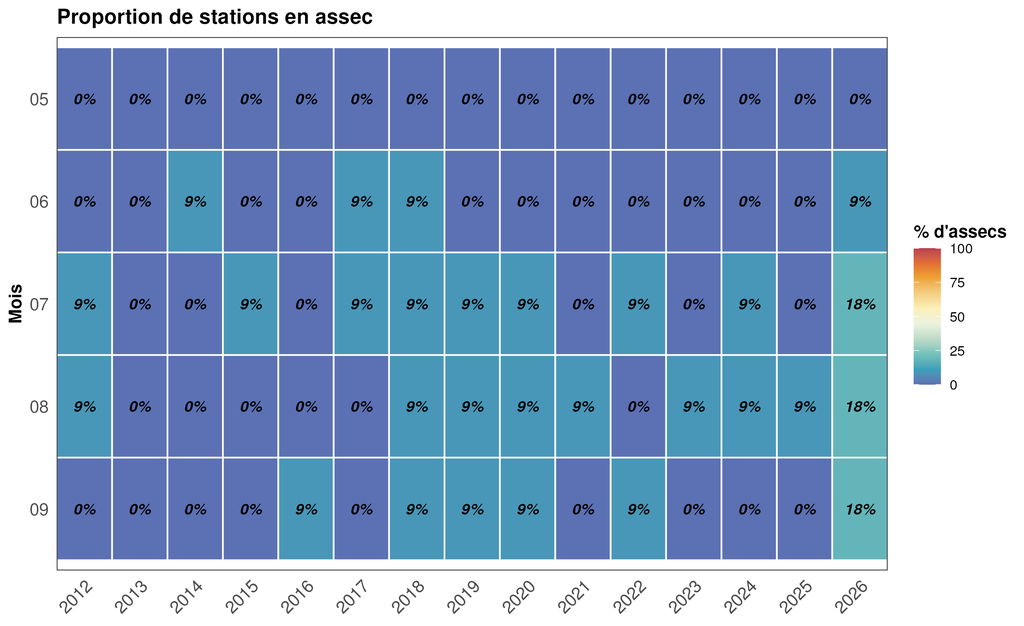

#### **Des assecs se suivant d’un mois sur l’autre**

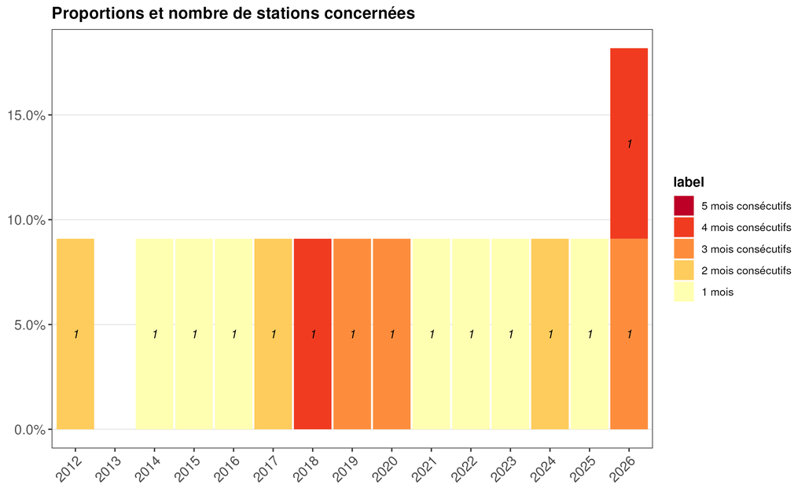

### 91

#### **Conditions d’écoulement lors des campagnes usuelles (mai à septembre 2026 )**

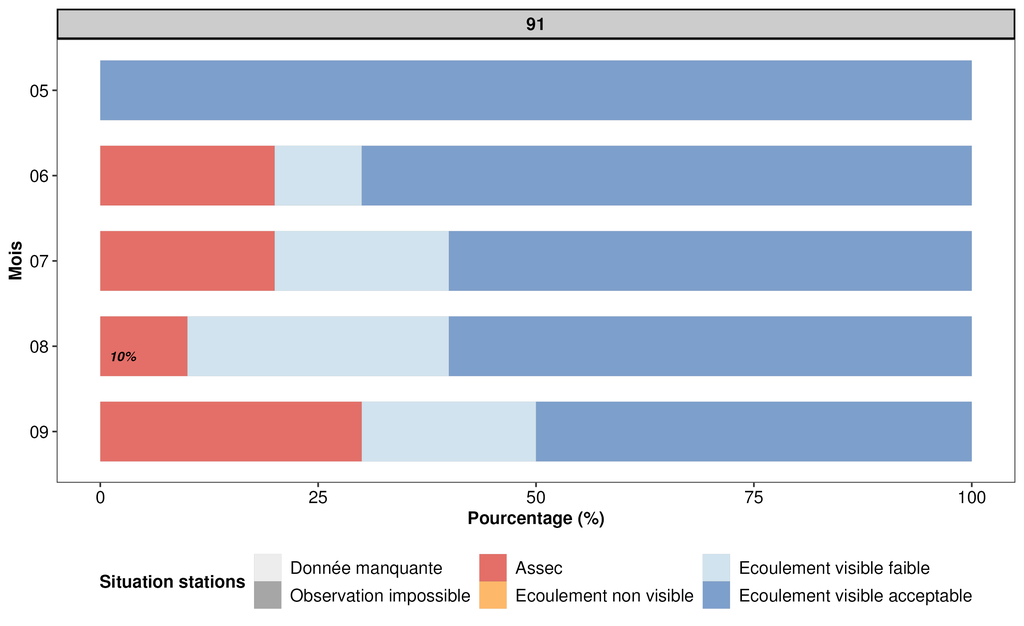

#### **Sévérité des assecs**

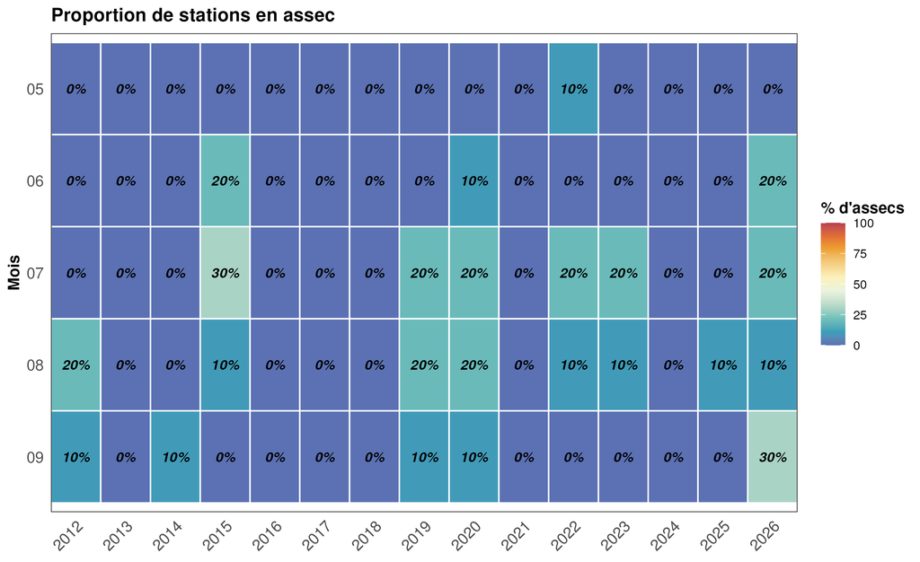

#### **Des assecs se suivant d’un mois sur l’autre**

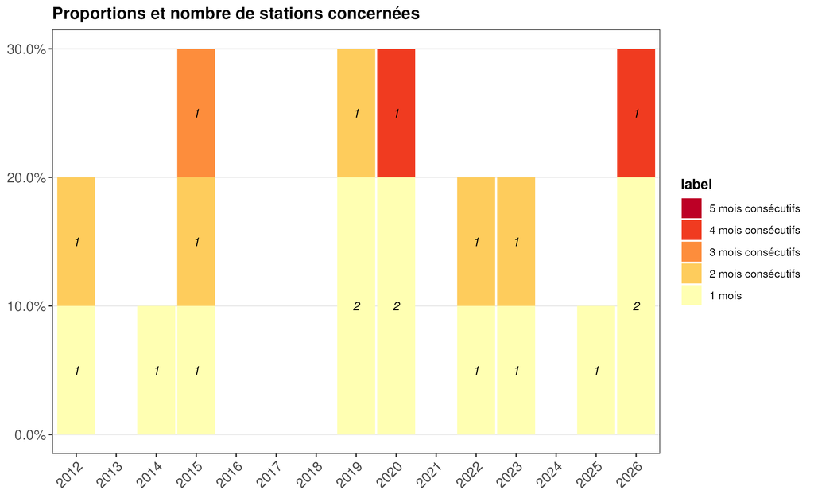

### 94

#### **Conditions d’écoulement lors des campagnes usuelles (mai à septembre 2026 )**

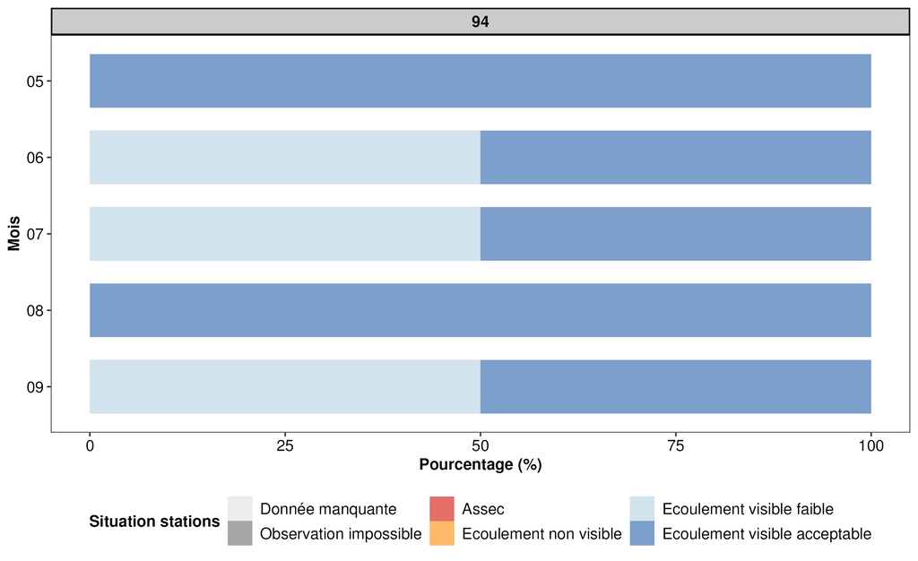

#### **Sévérité des assecs**

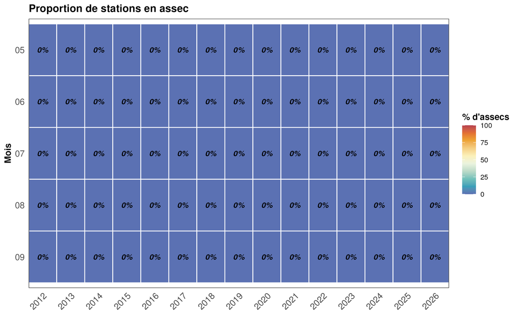

#### **Des assecs se suivant d’un mois sur l’autre**

[figure not shown]

### 95

#### **Conditions d’écoulement lors des campagnes usuelles (mai à septembre 2026 )**

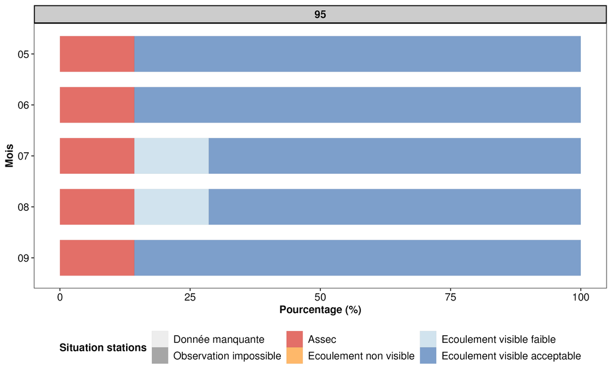

#### **Sévérité des assecs**

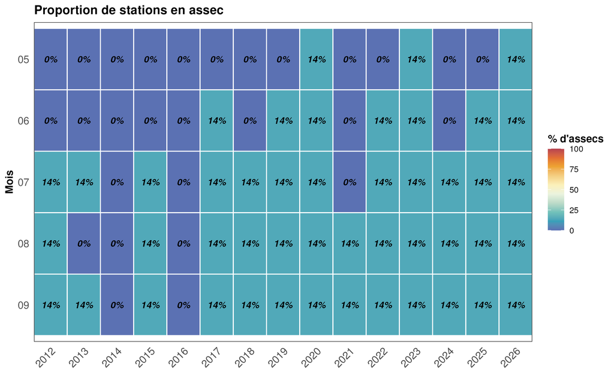

#### **Des assecs se suivant d’un mois sur l’autre**

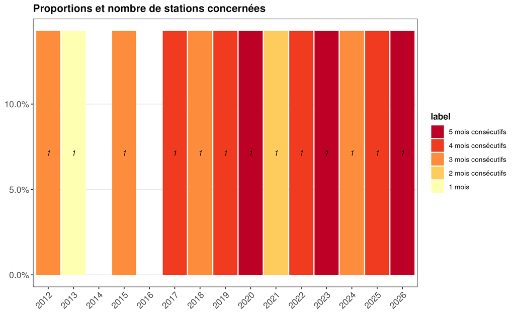

## Méthodologie

**Le réseau ONDE**

L’Observatoire national des étiages (ONDE) a pour objectif de contribuer à la surveillance et la compréhension des phénomènes d’étiages de certains cours d’eau métropolitains. Ce dispositif est porté par l’[Office français de la biodiversité](https://www.ofb.gouv.fr/).

**Les données**

Les données sont produites par les agents de l’Office français de la biodiversité à partir des observations de terrain réalisées sur les stations du réseau ONDE. Les données sont [mises à disposition](https://onde.eaufrance.fr/content/t%C3%A9l%C3%A9charger-les-donn%C3%A9es-des-campagnes-par-ann%C3%A9e) sous forme de fichiers annuels au format Excel. Le fichier de l’année en cours est mis à jour “au fil de l’eau” ; ou disponible sur la plateforme [Hubeau](https://hubeau.eaufrance.fr/) à partir des APIs disponibles (*API écoulement*).

**Les campagnes d’observations**

Deux types de campagnes d’observations sont distinguées :

- Les campagnes d’observations dites *usuelles*, réalisées sur chaque département au niveau national, au pas mensuel sur la période estivale (de mai à septembre) avec des observations systématiques à la date du 25 +/- 2 jours du mois.
- Les campagnes d’observations *complémentaires*, qui sont réalisées lorsque les conditions hydrologiques locales sont jugées sensibles (i.e, sécheresse). Ces observations *complémentaires* peuvent être réalisées sur un sous-ensemble (ou la totalité) des stations présentes en départements.

**La valorisation présentée ici**

La lecture des données, leur mise en forme et la production des graphiques sont effectués au moyen du logiciel *R* et de plusieurs *packages* (dont `ondetools`, `hubeau`, `tidyverse`, `ggplot2`, `rmarkdown`, `leaflet` et `mapview`).

Les fonds et couches pour les cartes proviennent de *leaflet*, *IGN*, *Propluvia*.